# In the Heat of Protest

Mason Meeks

Since the mid-2010s, it feels as though our world and society has changed a lot, especially with how we engage politically. Using data from the Crowd Counting Consortium ([found here](https://sites.google.com/view/crowdcountingconsortium/view-download-the-data?authuser=0)), I will be investigating the ebb and flow of protests from 2017 to present day. Specifically, I will be using protest data from July of each year since 2017. This has to do with the fact that I am curious how the relationship between COVID and the BLM movement affected protest frequency, and that it is only a few months away from elections during election cycles.

The data I will be using and this notebook can be found [here](https://mmeekstu.github.io/data-science/)

```python
# clone the course repository, change to right directory, and import libraries.
%cd /content
!git clone https://github.com/mmeekstu/data_science.git
%cd /content/data_science/'Project Data'/'July Data'
import pandas as pd
import numpy as np
import matplotlib.pyplot as plt
pd.set_option('display.max_columns', None)
```

```
/content
Cloning into 'data_science'...
remote: Enumerating objects: 150, done.
remote: Counting objects: 100% (16/16), done.
remote: Compressing objects: 100% (16/16), done.
remote: Total 150 (delta 5), reused 0 (delta 0), pack-reused 134
Receiving objects: 100% (150/150), 6.34 MiB | 16.85 MiB/s, done.
Resolving deltas: 100% (64/64), done.
/content/data_science/Project Data/July Data
```

# The Data

This data comes from the Crowd Counting Consortium which analyzes every protest, demonstration, rally, vigil, etc. throughout the U.S. The creators of this data have coded in many aspects of protests including its location, size, claim, groups, interactions among protesters, interactions among police, and many others. I chose this data because it should give me an abundance of information that will allow me to ask and potentially answer many types of questions. The initial question I hope to investigate with this milestone is how the frequency of protests and number of protesters have changed since 2017. With major elections, COVID, and massive public responses to policies and governmental actions, I expect to find a lot of interesting statistics that will shape the next stages of this project.

# ETL

```python
# Reading in csv files
df_2017 = pd.read_csv('Crowd Estimates July 2017 - Tally.csv')
df_2018 = pd.read_csv('Crowd Estimates July 2018 - Tally.csv')
df_2019 = pd.read_csv('Crowd Estimates July 2019 - Tally.csv')
df_2020 = pd.read_csv('Crowd Estimates July 2020 - Tally.csv')
df_2021 = pd.read_csv('Crowd Estimates July 2021 - Tally.csv')
df_2022 = pd.read_csv('Crowd Estimates July 2022 - Tally.csv')
df_2023 = pd.read_csv('Crowd Estimates July 2023 - Tally.csv')
```

After reading the csv files in, I am going to add a year column to each with their corresponding year. This will make grouping them quick and simple later on.

```python
# Adding a year column to each
df_2017['Year'] = 2017
df_2018['Year'] = 2018
df_2019['Year'] = 2019
df_2020['Year'] = 2020
df_2021['Year'] = 2021
df_2022['Year'] = 2022
df_2023['Year'] = 2023
```

```python
# Creating a list for easy access
df_list = list([df_2017, df_2018, df_2019, df_2020, df_2021, df_2022, df_2023])
```

Now for a quick display of the first row of each file. This will show how messy or neat the data is, and allow me to understand where I need to start organizing and tidying.

```python
for df in df_list:
  display(df.head(1))
```

|  | CityTown | Location | StateTerritory | Country | Date | EstimateText | EstimateLow | BestGuess | EstimateHigh | AdjustedLow | AdjustedHigh | Actor | Claim | Pro(2)/Anti(1) | EventType | ReportedArrests | ReportedParticipantInjuries | ReportedPoliceInjuries | ReportedPropertyDamage | TownsCities | Events | Source1 | Source2 | Source3 | Misc. | Unnamed: 25 | Unnamed: 26 | Unnamed: 27 | Year |
| --- | --- | --- | --- | --- | --- | --- | --- | --- | --- | --- | --- | --- | --- | --- | --- | --- | --- | --- | --- | --- | --- | --- | --- | --- | --- | --- | --- | --- | --- |
| 0 | Augusta | Outside State House | ME | US | 2017-07-01 | about 150; more than 150 | 150.0 | NaN | 150.0 | NaN | NaN | Maine State Employees Association | Protesting ME government shutdown | 0 | protest | 0 | 0 | 0 | 0.0 | 1 | 1 | http://mainepublic.org/post/state-workers-prot... | http://wgme.com/news/local/breaking-state-gove... | http://www.pressherald.com/2017/07/01/out-of-w... | NaN | NaN | NaN | NaN | 2017 |

|  | CityTown | Location | StateTerritory | Country | Date | EstimateText | EstimateLow | BestGuess | EstimateHigh | AdjustedLow | AdjustedHigh | Actor | Claim | Pro(2)/Anti(1) | EventType | ReportedArrests | ReportedParticipantInjuries | ReportedPoliceInjuries | ReportedPropertyDamage | TownsCities | Events | Source1 | Source2 | Source3 | Misc. | Unnamed: 25 | Year |
| --- | --- | --- | --- | --- | --- | --- | --- | --- | --- | --- | --- | --- | --- | --- | --- | --- | --- | --- | --- | --- | --- | --- | --- | --- | --- | --- | --- |
| 0 | Atlanta | Atlanta City Detention Center | GA | US | 2018-07-01 | dozens | 24.0 | NaN | 24.0 | NaN | NaN | Families Belong Together | against jailing and separating immigrant child... | 1.0 | protest | 1.0 | 0.0 | 0.0 | 0.0 | 1.0 | 1.0 | https://act.moveon.org/event/families-belong-t... | https://www.ajc.com/news/breaking-news/thousan... | https://www.ajc.com/news/breaking-news/arreste... | Continuation of FBT protest one day earlier. I... | NaN | 2018 |

|  | City | Location | County | StateTerritory | Country | Date | EstimateText | EstimateLow | BestGuess | EstimateHigh | AdjustedLow | AdjustedHigh | Actor | Claim | Pro(2)/Anti(1) | EventType | ReportedArrests | ReportedParticipantInjuries | ReportedPoliceInjuries | ReportedPropertyDamage | TownsCities | Events | Source1 | Source2 | Source3 | Misc. | Unnamed: 26 | Unnamed: 27 | Year |
| --- | --- | --- | --- | --- | --- | --- | --- | --- | --- | --- | --- | --- | --- | --- | --- | --- | --- | --- | --- | --- | --- | --- | --- | --- | --- | --- | --- | --- | --- |
| 0 | Baltimore | City Hall | NaN | MD | US | 2019-07-01 | NaN | NaN | NaN | NaN | NaN | NaN | customers, advocacy groups | water rates going up by 10% as the Board of Pu... | 0 | protest | 0.0 | 0.0 | 0.0 | 0.0 | 0.0 | 1.0 | https://www.wbaltv.com/article/protest-water-r... | NaN | NaN | NaN | NaN | NaN | 2019 |

|  | CityTown | Location | County | StateTerritory | Country | Date | EstimateText | EstimateLow | BestGuess | EstimateHigh | AdjustedLow | AdjustedHigh | Actor | Claim | Pro(2)/Anti(1) | EventType | ReportedArrests | ReportedParticipantInjuries | ReportedPoliceInjuries | ReportedPropertyDamage | TownsCities | Events | MacroEvent | Misc. | Source1 | Source2 | Source3 | Source4 | Source5 | … |
| --- | --- | --- | --- | --- | --- | --- | --- | --- | --- | --- | --- | --- | --- | --- | --- | --- | --- | --- | --- | --- | --- | --- | --- | --- | --- | --- | --- | --- | --- | --- |
| 0 | Ashland | Memorial Park; streets of Ashland; Highway 13 ... | NaN | WI | US | 2020-07-01 | NaN | NaN | NaN | NaN | NaN | NaN | water protectors | against recloation of Enbridge Line 5 Pipeline... | 1 | protest | 0 | 0 | 0.0 | 0.0 | 1 | 1 | NaN | NaN | https://kbjr6.com/2020/07/01/protesters-march-... | NaN | NaN | NaN | NaN | … |

|  | date | locality | state | location | title | size_text | size_low | size_high | organizations | participants | claims | valence | event_type | police_measures | participant_measures | police_injuries | participant_injuries | arrests | property_damage | police_deaths | participant_deaths | macroevent | notes | coder | source1 | source2 | source3 | source4 | source5 | … |
| --- | --- | --- | --- | --- | --- | --- | --- | --- | --- | --- | --- | --- | --- | --- | --- | --- | --- | --- | --- | --- | --- | --- | --- | --- | --- | --- | --- | --- | --- | --- |
| 0 | 2021-07-01 | Addison | IL | Portillo's Food Service | NaN | 17 | 17.0 | 17.0 | Arise Chicago | workers | for better working conditions and higher pay f... | 0.0 | strike; picket | NaN | NaN | NaN | NaN | NaN | NaN | NaN | NaN | NaN | NaN | NaN | https://chicago.suntimes.com/2021/7/2/22561028... | NaN | NaN | NaN | NaN | … |

|  | date | locality | state | location | title | size_text | size_low | size_high | organizations | participants | claims | valence | event_type | police_measures | participant_measures | police_injuries | participant_injuries | arrests | property_damage | police_deaths | participant_deaths | macroevent | notes | coder | source1 | source2 | source3 | source4 | source5 | … |
| --- | --- | --- | --- | --- | --- | --- | --- | --- | --- | --- | --- | --- | --- | --- | --- | --- | --- | --- | --- | --- | --- | --- | --- | --- | --- | --- | --- | --- | --- | --- |
| 0 | 2022-07-01 | Akron | OH | Harold K. Stubbs Justice Center | NaN | about 20 | 20.0 | 20.0 | The Freedom BLOC | NaN | for justice for Jayland Walker, against police... | 1.0 | protest | NaN | conversation with counter-protester | NaN | NaN | NaN | NaN | NaN | NaN | 20220701-akron-jaylandwalker | NaN | NaN | https://twitter.com/sahrasulaiman/status/15431... | https://fox8.com/news/elected-officials-callin... | https://www.wkyc.com/article/news/local/akron/... | https://www.beaconjournal.com/story/news/2022/... | https://www.instagram.com/p/Cfcmqv6JPtD/ | … |

|  | date | locality | state | location | title | size_text | size_low | size_high | organizations | participants | claims | valence | event_type | police_measures | participant_measures | police_injuries | participant_injuries | arrests | property_damage | police_deaths | participant_deaths | macroevent | notes | coder | source1 | source2 | source3 | source4 | source5 | … |
| --- | --- | --- | --- | --- | --- | --- | --- | --- | --- | --- | --- | --- | --- | --- | --- | --- | --- | --- | --- | --- | --- | --- | --- | --- | --- | --- | --- | --- | --- | --- |
| 0 | 2023-07-01 | Aguadilla | PR | NaN | Campamiento Pelicano | NaN | NaN | NaN | Citizens' Victory Movement | NaN | against illegal construction at historic Muell... | 0 | demonstration | NaN | protest encampment | NaN | NaN | NaN | NaN | NaN | NaN | NaN | NaN | NaN | https://twitter.com/Vaquero2XL/status/16102838... | https://twitter.com/Vaquero2XL/status/16201912... | https://twitter.com/Vaquero2XL/status/16204427... | https://twitter.com/latinorebels/status/162382... | NaN | … |

There are a lot of usesless columns that need to be dropped. Also, this data is quite messy and is not the most consistently titled throughout the years. I am just going to run some for loops to iterate through the columns to drop what I don't want.

```python
# Dropping a lot of data that will not be needed for the project
for (cName, cData) in df_2017.iteritems():
    if ("source" in cName) | ('Source' in cName) | ('macroevent' in cName) | ('MacroEvent' in cName) | ('Misc.' in cName) | ('Unnamed' in cName) | ('notes' in cName) | ('coder' in cName) | ('TownsCities' in cName) | ('Events' in cName) | ('BestGuess' in cName) | ('AdjustedLow' in cName) | ('AdjustedHigh' in cName) | ('EstimateText' in cName) | ('County' in cName) | ('size_text' in cName) | ('title' in cName):
      df_2017 = df_2017.drop(columns = cName)
for (cName, cData) in df_2018.iteritems():
    if ("source" in cName) | ('Source' in cName) | ('macroevent' in cName) | ('MacroEvent' in cName) | ('Misc.' in cName) | ('Unnamed' in cName) | ('notes' in cName) | ('coder' in cName) | ('TownsCities' in cName) | ('Events' in cName) | ('BestGuess' in cName) | ('AdjustedLow' in cName) | ('AdjustedHigh' in cName) | ('EstimateText' in cName) | ('County' in cName) | ('size_text' in cName) | ('title' in cName):
      df_2018 = df_2018.drop(columns = cName)
for (cName, cData) in df_2019.iteritems():
  if ("source" in cName) | ('Source' in cName) | ('macroevent' in cName) | ('MacroEvent' in cName) | ('Misc.' in cName) | ('Unnamed' in cName) | ('notes' in cName) | ('coder' in cName) | ('TownsCities' in cName) | ('Events' in cName) | ('BestGuess' in cName) | ('AdjustedLow' in cName) | ('AdjustedHigh' in cName) | ('EstimateText' in cName) | ('County' in cName) | ('size_text' in cName) | ('title' in cName):
    df_2019 = df_2019.drop(columns = cName)
for (cName, cData) in df_2020.iteritems():
    if ("source" in cName) | ('Source' in cName) | ('macroevent' in cName) | ('MacroEvent' in cName) | ('Misc.' in cName) | ('Unnamed' in cName) | ('notes' in cName) | ('coder' in cName) | ('TownsCities' in cName) | ('Events' in cName) | ('BestGuess' in cName) | ('AdjustedLow' in cName) | ('AdjustedHigh' in cName) | ('EstimateText' in cName) | ('County' in cName) | ('size_text' in cName) | ('title' in cName):
      df_2020 = df_2020.drop(columns = cName)
for (cName, cData) in df_2021.iteritems():
    if ("source" in cName) | ('Source' in cName) | ('macroevent' in cName) | ('MacroEvent' in cName) | ('Misc.' in cName) | ('Unnamed' in cName) | ('notes' in cName) | ('coder' in cName) | ('TownsCities' in cName) | ('Events' in cName) | ('BestGuess' in cName) | ('AdjustedLow' in cName) | ('AdjustedHigh' in cName) | ('EstimateText' in cName) | ('County' in cName) | ('size_text' in cName) | ('title' in cName):
      df_2021 = df_2021.drop(columns = cName)
for (cName, cData) in df_2022.iteritems():
    if ("source" in cName) | ('Source' in cName) | ('macroevent' in cName) | ('MacroEvent' in cName) | ('Misc.' in cName) | ('Unnamed' in cName) | ('notes' in cName) | ('coder' in cName) | ('TownsCities' in cName) | ('Events' in cName) | ('BestGuess' in cName) | ('AdjustedLow' in cName) | ('AdjustedHigh' in cName) | ('EstimateText' in cName) | ('County' in cName) | ('size_text' in cName) | ('title' in cName):
      df_2022 = df_2022.drop(columns = cName)
for (cName, cData) in df_2023.iteritems():
    if ("source" in cName) | ('Source' in cName) | ('macroevent' in cName) | ('MacroEvent' in cName) | ('Misc.' in cName) | ('Unnamed' in cName) | ('notes' in cName) | ('coder' in cName) | ('TownsCities' in cName) | ('Events' in cName) | ('BestGuess' in cName) | ('AdjustedLow' in cName) | ('AdjustedHigh' in cName) | ('EstimateText' in cName) | ('County' in cName) | ('size_text' in cName) | ('title' in cName):
      df_2023 = df_2023.drop(columns = cName)
```

```python
# Re-estabilshing the list
df_list = list([df_2017, df_2018, df_2019, df_2020, df_2021, df_2022, df_2023])
```

```python
# Let's see what we have now
for df in df_list:
  display(df.head(1))
```

|  | CityTown | Location | StateTerritory | Country | Date | EstimateLow | EstimateHigh | Actor | Claim | Pro(2)/Anti(1) | EventType | ReportedArrests | ReportedParticipantInjuries | ReportedPoliceInjuries | ReportedPropertyDamage | Year |
| --- | --- | --- | --- | --- | --- | --- | --- | --- | --- | --- | --- | --- | --- | --- | --- | --- |
| 0 | Augusta | Outside State House | ME | US | 2017-07-01 | 150.0 | 150.0 | Maine State Employees Association | Protesting ME government shutdown | 0 | protest | 0 | 0 | 0 | 0.0 | 2017 |

|  | CityTown | Location | StateTerritory | Country | Date | EstimateLow | EstimateHigh | Actor | Claim | Pro(2)/Anti(1) | EventType | ReportedArrests | ReportedParticipantInjuries | ReportedPoliceInjuries | ReportedPropertyDamage | Year |
| --- | --- | --- | --- | --- | --- | --- | --- | --- | --- | --- | --- | --- | --- | --- | --- | --- |
| 0 | Atlanta | Atlanta City Detention Center | GA | US | 2018-07-01 | 24.0 | 24.0 | Families Belong Together | against jailing and separating immigrant child... | 1.0 | protest | 1.0 | 0.0 | 0.0 | 0.0 | 2018 |

|  | City | Location | StateTerritory | Country | Date | EstimateLow | EstimateHigh | Actor | Claim | Pro(2)/Anti(1) | EventType | ReportedArrests | ReportedParticipantInjuries | ReportedPoliceInjuries | ReportedPropertyDamage | Year |
| --- | --- | --- | --- | --- | --- | --- | --- | --- | --- | --- | --- | --- | --- | --- | --- | --- |
| 0 | Baltimore | City Hall | MD | US | 2019-07-01 | NaN | NaN | customers, advocacy groups | water rates going up by 10% as the Board of Pu... | 0 | protest | 0.0 | 0.0 | 0.0 | 0.0 | 2019 |

|  | CityTown | Location | StateTerritory | Country | Date | EstimateLow | EstimateHigh | Actor | Claim | Pro(2)/Anti(1) | EventType | ReportedArrests | ReportedParticipantInjuries | ReportedPoliceInjuries | ReportedPropertyDamage | Year |
| --- | --- | --- | --- | --- | --- | --- | --- | --- | --- | --- | --- | --- | --- | --- | --- | --- |
| 0 | Ashland | Memorial Park; streets of Ashland; Highway 13 ... | WI | US | 2020-07-01 | NaN | NaN | water protectors | against recloation of Enbridge Line 5 Pipeline... | 1 | protest | 0 | 0 | 0.0 | 0.0 | 2020 |

|  | date | locality | state | location | size_low | size_high | organizations | participants | claims | valence | event_type | police_measures | participant_measures | police_injuries | participant_injuries | arrests | property_damage | police_deaths | participant_deaths | Year |
| --- | --- | --- | --- | --- | --- | --- | --- | --- | --- | --- | --- | --- | --- | --- | --- | --- | --- | --- | --- | --- |
| 0 | 2021-07-01 | Addison | IL | Portillo's Food Service | 17.0 | 17.0 | Arise Chicago | workers | for better working conditions and higher pay f... | 0.0 | strike; picket | NaN | NaN | NaN | NaN | NaN | NaN | NaN | NaN | 2021 |

|  | date | locality | state | location | size_low | size_high | organizations | participants | claims | valence | event_type | police_measures | participant_measures | police_injuries | participant_injuries | arrests | property_damage | police_deaths | participant_deaths | Year |
| --- | --- | --- | --- | --- | --- | --- | --- | --- | --- | --- | --- | --- | --- | --- | --- | --- | --- | --- | --- | --- |
| 0 | 2022-07-01 | Akron | OH | Harold K. Stubbs Justice Center | 20.0 | 20.0 | The Freedom BLOC | NaN | for justice for Jayland Walker, against police... | 1.0 | protest | NaN | conversation with counter-protester | NaN | NaN | NaN | NaN | NaN | NaN | 2022 |

|  | date | locality | state | location | size_low | size_high | organizations | participants | claims | valence | event_type | police_measures | participant_measures | police_injuries | participant_injuries | arrests | property_damage | police_deaths | participant_deaths | Year |
| --- | --- | --- | --- | --- | --- | --- | --- | --- | --- | --- | --- | --- | --- | --- | --- | --- | --- | --- | --- | --- |
| 0 | 2023-07-01 | Aguadilla | PR | NaN | NaN | NaN | Citizens' Victory Movement | NaN | against illegal construction at historic Muell... | 0 | demonstration | NaN | protest encampment | NaN | NaN | NaN | NaN | NaN | NaN | 2023 |

It is defintely already more manageable and organized. However, there are a lot of inconsistencies throughout the naming. There seemed to be a large change in 2021 with how the investigators coded the data. I will go ahead and make the names more consistent.

```python
# Renamming inconsistent data
df_2017 = df_2017.rename(columns={"CityTown": "City", "StateTerritory": "State", 'Actor': 'Actors', 'Pro(2)/Anti(1)': 'Political Affiliation'})
df_2018 = df_2018.rename(columns={"CityTown": "City", "StateTerritory": "State", 'Actor': 'Actors', 'Pro(2)/Anti(1)': 'Political Affiliation'})
df_2019 = df_2019.rename(columns={"StateTerritory": "State", 'Actor': 'Actors', 'Pro(2)/Anti(1)': 'Political Affiliation'})
df_2020 = df_2020.rename(columns={"CityTown": "City", "StateTerritory": "State", 'Actor': 'Actors', 'Pro(2)/Anti(1)': 'Political Affiliation'})
df_2021 = df_2021.rename(columns={'date': 'Date', 'locality': 'City', 'location': 'Location', 'state': 'State', 'size_low': 'EstimateLow', 'size_high': 'EstimateHigh', 'claims': 'Claim', 'event_type': 'EventType', 'participants': 'Actors', 'valence': 'Political Affiliation', 'police_injuries': 'ReportedPoliceInjuries', 'participant_injuries': 'ReportedParticipantInjuries', 'arrests': 'ReportedArrests', 'property_damage': 'ReportedPropertyDamage'})
df_2022 = df_2022.rename(columns={'date': 'Date', 'locality': 'City', 'location': 'Location', 'state': 'State', 'size_low': 'EstimateLow', 'size_high': 'EstimateHigh', 'claims': 'Claim', 'event_type': 'EventType', 'participants': 'Actors', 'valence': 'Political Affiliation', 'police_injuries': 'ReportedPoliceInjuries', 'participant_injuries': 'ReportedParticipantInjuries', 'arrests': 'ReportedArrests', 'property_damage': 'ReportedPropertyDamage'})
df_2023 = df_2023.rename(columns={'date': 'Date', 'locality': 'City', 'location': 'Location', 'state': 'State', 'size_low': 'EstimateLow', 'size_high': 'EstimateHigh', 'claims': 'Claim', 'event_type': 'EventType', 'participants': 'Actors', 'valence': 'Political Affiliation', 'police_injuries': 'ReportedPoliceInjuries', 'participant_injuries': 'ReportedParticipantInjuries', 'arrests': 'ReportedArrests', 'property_damage': 'ReportedPropertyDamage'})
```

```python
# Re-establishing the list
df_list = list([df_2017, df_2018, df_2019, df_2020, df_2021, df_2022, df_2023])
```

```python
# Much more consistent
for df in df_list:
  display(df.head(1))
```

|  | City | Location | State | Country | Date | EstimateLow | EstimateHigh | Actors | Claim | Political Affiliation | EventType | ReportedArrests | ReportedParticipantInjuries | ReportedPoliceInjuries | ReportedPropertyDamage | Year |
| --- | --- | --- | --- | --- | --- | --- | --- | --- | --- | --- | --- | --- | --- | --- | --- | --- |
| 0 | Augusta | Outside State House | ME | US | 2017-07-01 | 150.0 | 150.0 | Maine State Employees Association | Protesting ME government shutdown | 0 | protest | 0 | 0 | 0 | 0.0 | 2017 |

|  | City | Location | State | Country | Date | EstimateLow | EstimateHigh | Actors | Claim | Political Affiliation | EventType | ReportedArrests | ReportedParticipantInjuries | ReportedPoliceInjuries | ReportedPropertyDamage | Year |
| --- | --- | --- | --- | --- | --- | --- | --- | --- | --- | --- | --- | --- | --- | --- | --- | --- |
| 0 | Atlanta | Atlanta City Detention Center | GA | US | 2018-07-01 | 24.0 | 24.0 | Families Belong Together | against jailing and separating immigrant child... | 1.0 | protest | 1.0 | 0.0 | 0.0 | 0.0 | 2018 |

|  | City | Location | State | Country | Date | EstimateLow | EstimateHigh | Actors | Claim | Political Affiliation | EventType | ReportedArrests | ReportedParticipantInjuries | ReportedPoliceInjuries | ReportedPropertyDamage | Year |
| --- | --- | --- | --- | --- | --- | --- | --- | --- | --- | --- | --- | --- | --- | --- | --- | --- |
| 0 | Baltimore | City Hall | MD | US | 2019-07-01 | NaN | NaN | customers, advocacy groups | water rates going up by 10% as the Board of Pu... | 0 | protest | 0.0 | 0.0 | 0.0 | 0.0 | 2019 |

|  | City | Location | State | Country | Date | EstimateLow | EstimateHigh | Actors | Claim | Political Affiliation | EventType | ReportedArrests | ReportedParticipantInjuries | ReportedPoliceInjuries | ReportedPropertyDamage | Year |
| --- | --- | --- | --- | --- | --- | --- | --- | --- | --- | --- | --- | --- | --- | --- | --- | --- |
| 0 | Ashland | Memorial Park; streets of Ashland; Highway 13 ... | WI | US | 2020-07-01 | NaN | NaN | water protectors | against recloation of Enbridge Line 5 Pipeline... | 1 | protest | 0 | 0 | 0.0 | 0.0 | 2020 |

|  | Date | City | State | Location | EstimateLow | EstimateHigh | organizations | Actors | Claim | Political Affiliation | EventType | police_measures | participant_measures | ReportedPoliceInjuries | ReportedParticipantInjuries | ReportedArrests | ReportedPropertyDamage | police_deaths | participant_deaths | Year |
| --- | --- | --- | --- | --- | --- | --- | --- | --- | --- | --- | --- | --- | --- | --- | --- | --- | --- | --- | --- | --- |
| 0 | 2021-07-01 | Addison | IL | Portillo's Food Service | 17.0 | 17.0 | Arise Chicago | workers | for better working conditions and higher pay f... | 0.0 | strike; picket | NaN | NaN | NaN | NaN | NaN | NaN | NaN | NaN | 2021 |

|  | Date | City | State | Location | EstimateLow | EstimateHigh | organizations | Actors | Claim | Political Affiliation | EventType | police_measures | participant_measures | ReportedPoliceInjuries | ReportedParticipantInjuries | ReportedArrests | ReportedPropertyDamage | police_deaths | participant_deaths | Year |
| --- | --- | --- | --- | --- | --- | --- | --- | --- | --- | --- | --- | --- | --- | --- | --- | --- | --- | --- | --- | --- |
| 0 | 2022-07-01 | Akron | OH | Harold K. Stubbs Justice Center | 20.0 | 20.0 | The Freedom BLOC | NaN | for justice for Jayland Walker, against police... | 1.0 | protest | NaN | conversation with counter-protester | NaN | NaN | NaN | NaN | NaN | NaN | 2022 |

|  | Date | City | State | Location | EstimateLow | EstimateHigh | organizations | Actors | Claim | Political Affiliation | EventType | police_measures | participant_measures | ReportedPoliceInjuries | ReportedParticipantInjuries | ReportedArrests | ReportedPropertyDamage | police_deaths | participant_deaths | Year |
| --- | --- | --- | --- | --- | --- | --- | --- | --- | --- | --- | --- | --- | --- | --- | --- | --- | --- | --- | --- | --- |
| 0 | 2023-07-01 | Aguadilla | PR | NaN | NaN | NaN | Citizens' Victory Movement | NaN | against illegal construction at historic Muell... | 0 | demonstration | NaN | protest encampment | NaN | NaN | NaN | NaN | NaN | NaN | 2023 |

Now we can really start doing something with the data. There are a few columns with inconsistent names or naming structures, but I did not want to go too deep into that part of the data for this stage of the project as I have not yet determined if it will be useful for the later stages.

I am going to go ahead and concatenate the tables now that naming is more consistent. This will allow me to more easily manage, transform, and analyze the data.

```python
df_full = pd.concat([df_2017, df_2018, df_2019, df_2020, df_2021, df_2022, df_2023])
```

```python
# Success. Here is what the new and final table looks like
df_full
```

|  | City | Location | State | Country | Date | EstimateLow | EstimateHigh | Actors | Claim | Political Affiliation | EventType | ReportedArrests | ReportedParticipantInjuries | ReportedPoliceInjuries | ReportedPropertyDamage | Year | organizations | police_measures | participant_measures | police_deaths | participant_deaths |
| --- | --- | --- | --- | --- | --- | --- | --- | --- | --- | --- | --- | --- | --- | --- | --- | --- | --- | --- | --- | --- | --- |
| 0 | Augusta | Outside State House | ME | US | 2017-07-01 | 150.0 | 150.0 | Maine State Employees Association | Protesting ME government shutdown | 0.0 | protest | 0 | 0 | 0 | 0.0 | 2017 | NaN | NaN | NaN | NaN | NaN |
| 1 | Austin | marched from Wooldridge Square Park to state c... | TX | US | 2017-07-01 | 100.0 | 200.0 | Texans United for America; Open Carry Texas | 1776 Freedom March in support of President Don... | 2.0 | rally; march | 0 | 0 | 0 | 0.0 | 2017 | NaN | NaN | NaN | NaN | NaN |
| 2 | Birmingham | from Kelly Ingram park to City Hall | AL | US | 2017-07-01 | 30.0 | 30.0 | Adelante Alabama Worker Center | Support sanctuary city ordinance | 1.0 | march | 0 | 0 | 0 | 0.0 | 2017 | NaN | NaN | NaN | NaN | NaN |
| 3 | Gettysburg | Gettysburg National Military Park | PA | US | 2017-07-01 | 24.0 | 200.0 | armed militia group members, Sons of Confedera... | "First Amendment" rally | 2.0 | rally | 0 | 1 | 0 | 0.0 | 2017 | NaN | NaN | NaN | NaN | NaN |
| 4 | Greeley | Outside Weld County Courthouse | CO | US | 2017-07-01 | NaN | NaN | General Protestors | Anti-Trump | 1.0 | protest | 0 | 0 | 0 | 0.0 | 2017 | NaN | NaN | NaN | NaN | NaN |
| ... | ... | ... | ... | ... | ... | ... | ... | ... | ... | ... | ... | ... | ... | ... | ... | ... | ... | ... | ... | ... | ... |
| 2016 | Washington | DC Central Detention Facility | DC | NaN | 2023-07-31 | NaN | NaN | NaN | for justice for people jailed or imprisoned fo... | 2.0 | vigil | NaN | NaN | NaN | NaN | 2023 | NaN | on scene | NaN | NaN | NaN |
| 2017 | Washington | DC Central Detention Facility | DC | NaN | 2023-07-31 | 4.0 | 5.0 | NaN | against vigil for jailed J6 participants, agai... | 1.0 | counter-protest | NaN | NaN | NaN | NaN | 2023 | DC RATS | on scene | megaphones | NaN | NaN |
| 2018 | Washington | Lafayette Square | DC | NaN | 2023-07-31 | NaN | NaN | NaN | for banning nuclear weapons, for peace | 0.0 | vigil | NaN | NaN | NaN | NaN | 2023 | NaN | NaN | NaN | NaN | NaN |
| 2019 | Wooster | Wooster Square | OH | NaN | 2023-07-31 | NaN | NaN | NaN | against racism, against police brutality | 1.0 | demonstration | NaN | NaN | NaN | NaN | 2023 | Wayne County Racial Justice Coalition | NaN | NaN | NaN | NaN |
| 2020 | Yonkers | Warburton Ave and Odell Ave | NY | NaN | 2023-07-31 | NaN | NaN | NaN | against police brutality, against racism, for ... | 1.0 | demonstration | NaN | NaN | NaN | NaN | 2023 | Northwest Yonkers Neighbors for Black Lives Ma... | NaN | NaN | NaN | NaN |

9295 rows × 21 columns

I do not like that Political Affiliation is in integer format, so I am going to remap the values to make more intuitive sense.

```python
# Remapping Political Affiliation to be more intuitive
df_full['Political Affiliation'] = df_full['Political Affiliation'].map({
    0.0: 'Neither',
    1.0: 'Left/Anti-Trump',
    2.0: 'Right/Pro-Trump'
})
```

Now that there is one, organized table, let's take a look at the dtypes to see what pandas thinks of the data.

```python
df_full.dtypes
```

```
City                            object
Location                        object
State                           object
Country                         object
Date                            object
EstimateLow                    float64
EstimateHigh                   float64
Actors                          object
Claim                           object
Political Affiliation           object
EventType                       object
ReportedArrests                 object
ReportedParticipantInjuries     object
ReportedPoliceInjuries          object
ReportedPropertyDamage          object
Year                             int64
organizations                   object
police_measures                 object
participant_measures            object
police_deaths                  float64
participant_deaths             float64
dtype: object
```

It's not too bad. There are only a few columns I want to change, specifically the estimate columns and death columns since counting the number of people via decimal does not make much sense.

```python
df_full = df_full.astype({'EstimateLow': 'Int64', 'EstimateHigh': 'Int64', 'police_deaths': 'Int64', 'participant_deaths': 'Int64'})
```

```python
# Better
df_full.dtypes
```

```
City                           object
Location                       object
State                          object
Country                        object
Date                           object
EstimateLow                     Int64
EstimateHigh                    Int64
Actors                         object
Claim                          object
Political Affiliation          object
EventType                      object
ReportedArrests                object
ReportedParticipantInjuries    object
ReportedPoliceInjuries         object
ReportedPropertyDamage         object
Year                            int64
organizations                  object
police_measures                object
participant_measures           object
police_deaths                   Int64
participant_deaths              Int64
dtype: object
```

I do not want to make the 'Reported' columns booleans until I want to start doing something with that data because it will be somewhat challenging since, again, that is not in the scope of this stage and I am not yet sure if I will need it in the next.

# EDA

Now let's take a look at some summary statistics and graphs. I am just going to group by the year column that I made earlier and tally total observations and take the summation and mean of the estimated high and low columns to get a more accurate representation of the data. This will give me some base-line information to begin forming questions and directing analyses.

| Year | City | Date |
| --- | --- | --- |
| 2017 | 750 | 750 |
| 2018 | 757 | 756 |
| 2019 | 510 | 510 |
| 2020 | 835 | 835 |
| 2021 | 1896 | 1896 |
| 2022 | 2523 | 2523 |
| 2023 | 2017 | 2021 |

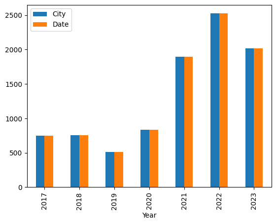

```python
# Grouping Years to find total number of observations
df_Counts = df_full.groupby('Year')[['City', 'Date']].count() # Counts for City and Date are just a few off so I used both for accuracy's sake
display(df_Counts)
df_Counts.plot.bar()
```

| Year | EstimateLow |
| --- | --- |
| 2017 | 85471 |
| 2018 | 72275 |
| 2019 | 312529 |
| 2020 | 60282 |
| 2021 | 70619 |
| 2022 | 146052 |
| 2023 | 349572 |

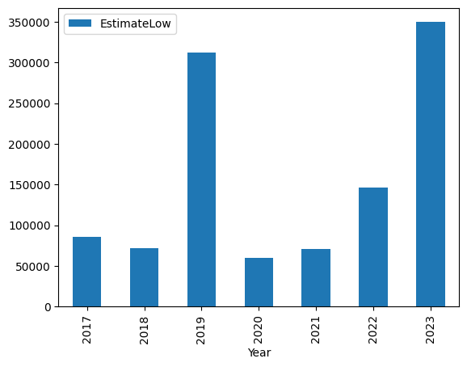

```python
# Grouping 'EstimatedLow' and summing
df_EL_sum = df_full.groupby('Year')[['EstimateLow']].sum()
display(df_EL_sum)
df_EL_sum.plot.bar()
```

| Year | EstimateHigh |
| --- | --- |
| 2017 | 107918 |
| 2018 | 74256 |
| 2019 | 316192 |
| 2020 | 67828 |
| 2021 | 126768 |
| 2022 | 175256 |
| 2023 | 512559 |

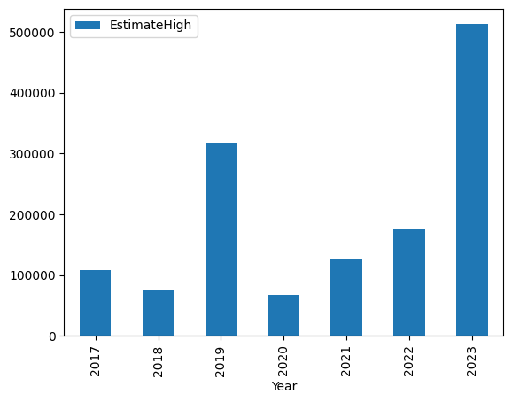

```python
# Grouping 'EstimatedHigh' and summing
df_EH_sum = df_full.groupby('Year')[['EstimateHigh']].sum()
display(df_EH_sum)
df_EH_sum.plot.bar()
```

| Year | EstimateLow |
| --- | --- |
| 2017 | 177.325726 |
| 2018 | 154.104478 |
| 2019 | 976.653125 |
| 2020 | 137.630137 |
| 2021 | 90.075255 |
| 2022 | 148.729124 |
| 2023 | 520.196429 |

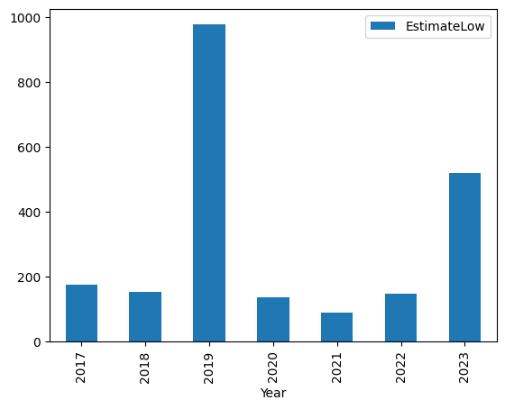

```python
# Grouping 'EstimatedLow' and averaging
df_EL_avg = df_full.groupby('Year')[['EstimateLow']].mean()
display(df_EL_avg)
df_EL_avg.plot.bar()
```

| Year | EstimateHigh |
| --- | --- |
| 2017 | 223.432712 |
| 2018 | 158.328358 |
| 2019 | 994.314465 |
| 2020 | 154.858447 |
| 2021 | 161.693878 |
| 2022 | 178.650357 |
| 2023 | 762.736607 |

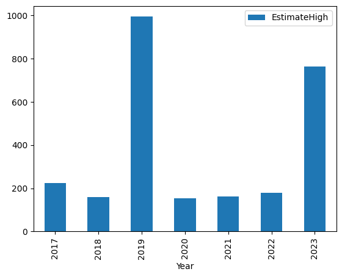

```python
# Grouping 'EstimatedHigh' and averaging
df_EH_avg = df_full.groupby('Year')[['EstimateHigh']].mean()
display(df_EH_avg)
df_EH_avg.plot.bar()
```

# Conclusions on the Data and Where to Go From Here

Another strange aspect of this information is that the number of protesters shoots up quite intensely in 2019 and 2023 from a rather stable frequency. I was rather shocked to see the 2020 numbers so low since, even during the lockdown, protests were at the forefront of our media. Futhermore, the fact that 2019 had not only the fewest number of protests while also having the highest average number of protesters per protest and some of the highest numbers of protesters throughout all protests is quite shocking.